# R for Applied Economists: Session 4

# Today’s plan

- R/LaTeX integration
- Graphs
- Wrap up

# Graphing

## Introduction

As is so often the case, there are multiple packages for doing graphs in R. There is base functionality, which hardly anyone seems to use, and then two main contenders: ggplot2 and lattice. Here’s an introduction to ggplot2.

```r
library(ggplot2)

mycars <- mtcars
mycars$car <- rownames(mycars)
rownames(mycars) <- NULL
```

There are three components to any ggplot call:

- data
- “aesthetic mappings” map data to visual properties
- geometric objects (points, lines etc)

## Basic examples

Plot points mpg (x-axis) vs wt (y-axis)

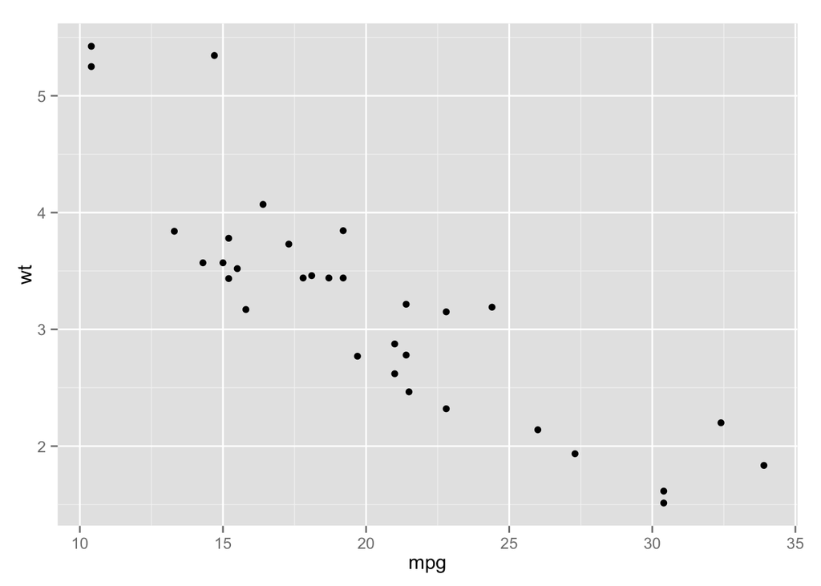

```r
ggplot(data = mycars, aes(x = mpg, y = wt)) +
  geom_point()
```

Add a lowess smoother:

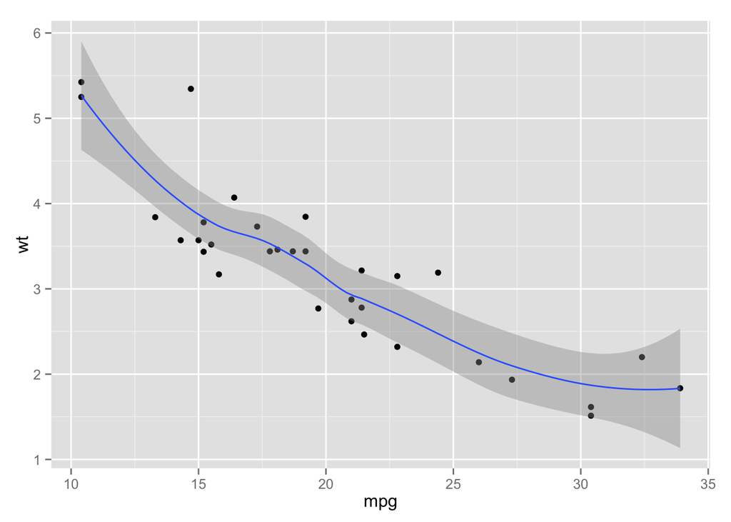

```r
ggplot(mycars, aes(x = mpg, y = wt)) +
    geom_point() +
    geom_smooth()
```

Or labels:

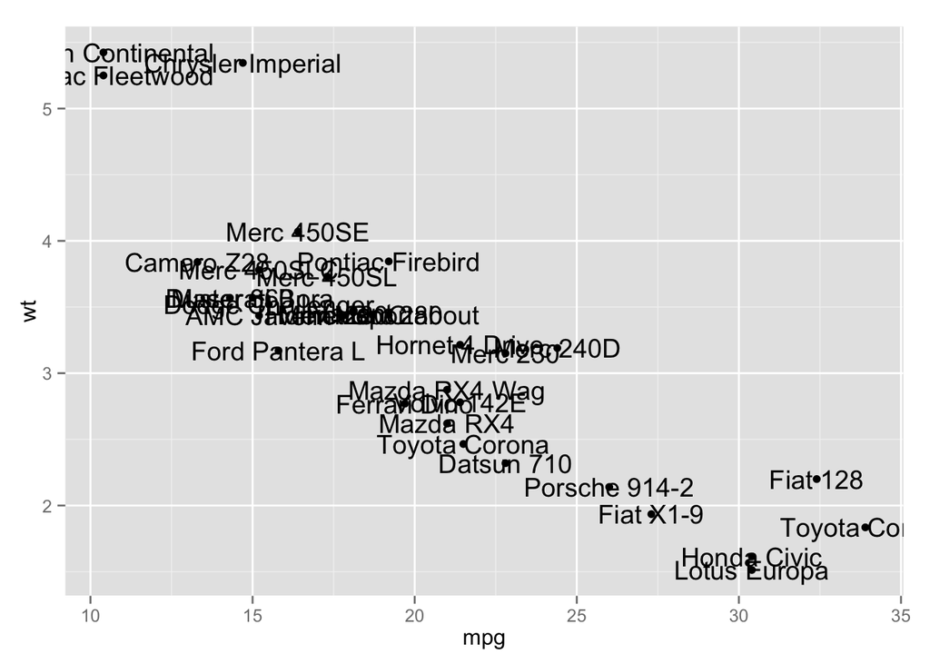

```r
ggplot(mycars, aes(x = mpg, y = wt)) +
    geom_point()  +
    geom_text(aes(label = car))
```

Provide options to geom functions:

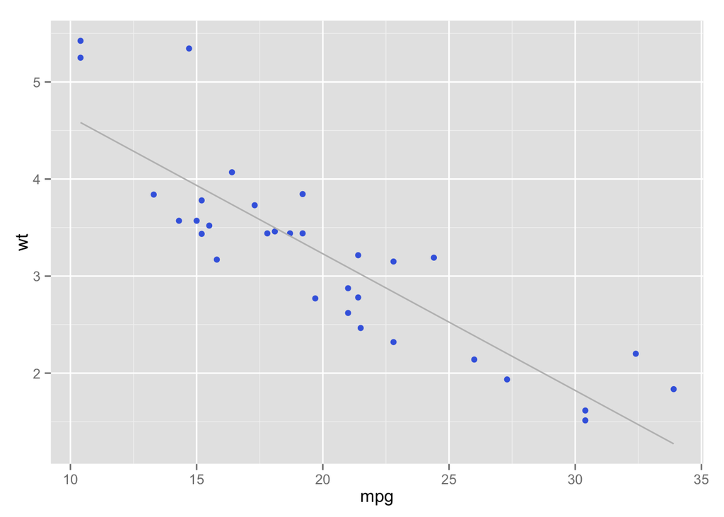

```r
ggplot(mycars, aes(x = mpg, y = wt)) +
        geom_point(color="royalblue", size = 2)  +
        geom_smooth(method=lm, se = FALSE, color="grey")
```

Set aesthetic mappings for individual geoms, e.g. color:

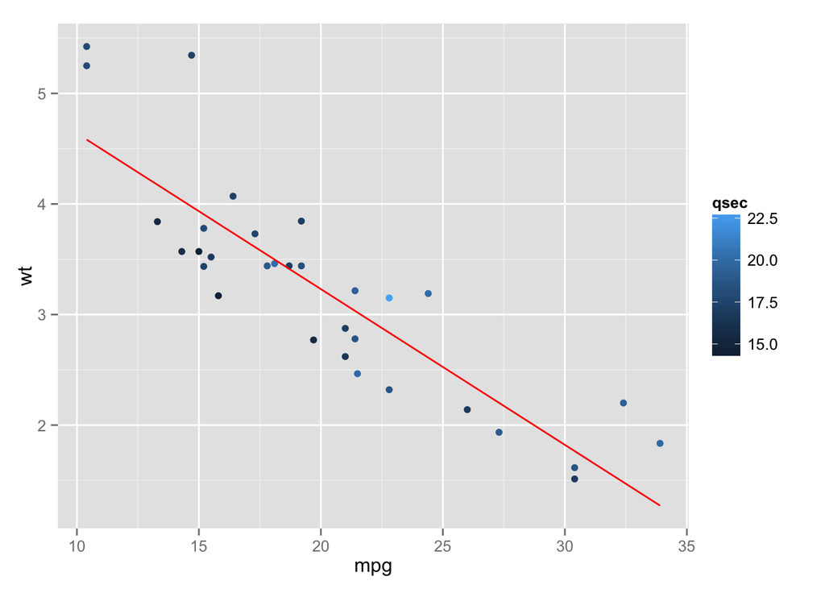

```r
ggplot(mycars,  aes(x = mpg, y = wt)) +
        geom_point(aes(color=qsec)) +
        geom_smooth(method=lm, se = FALSE, color="red")
```

.. or size:

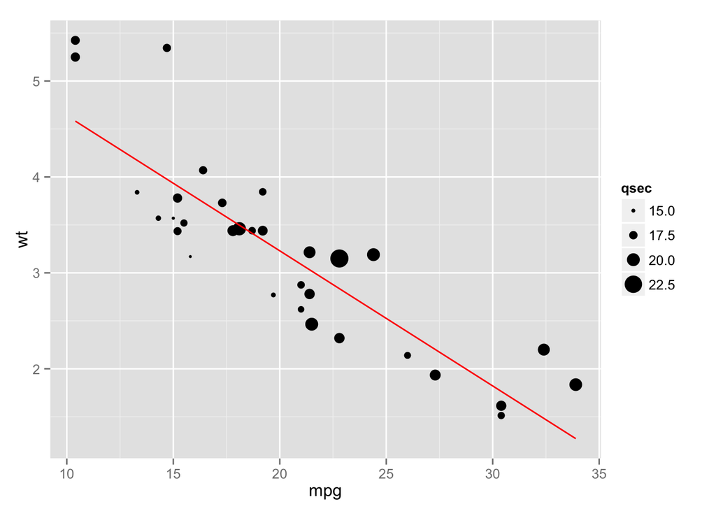

```r
ggplot(mycars,  aes(x = mpg, y = wt)) +
        geom_point(aes(size=qsec)) +
        geom_smooth(method=lm, se = FALSE, color="red")
```

.. or shape (having turned “am”" into a factor):

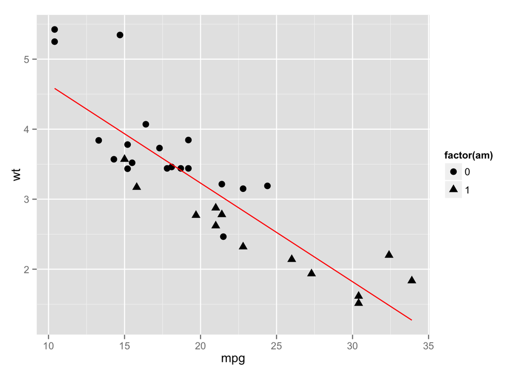

```r
ggplot(mycars,  aes(x = mpg, y = wt)) +
        geom_point(aes(shape=factor(am)),size=3) +
        geom_smooth(method=lm, se = FALSE, color="red")
```

See the difference to setting the aesthetic mapping on the whole plot:

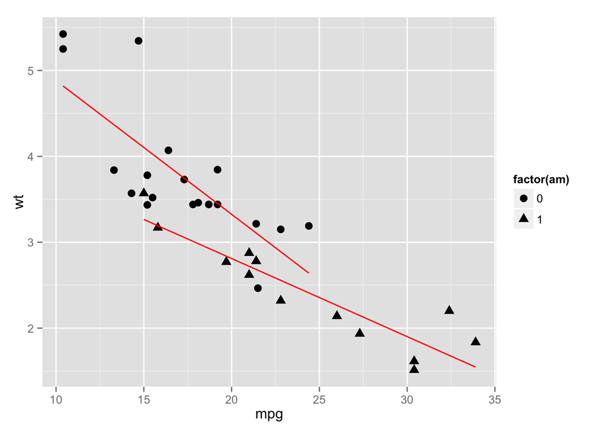

```r
ggplot(mycars,  aes(x = mpg, y = wt, shape=factor(am))) +
        geom_point(size=3) +
        geom_smooth(method=lm, se = FALSE, color="red")
```

Set title and axis labels:

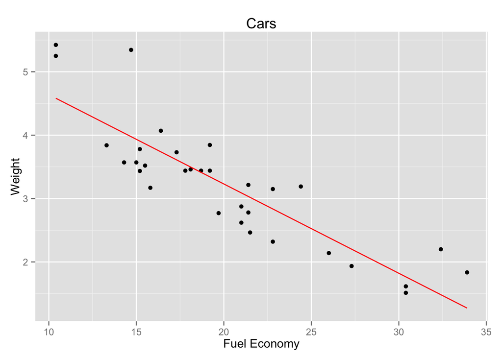

```r
ggplot(mycars,  aes(x = mpg, y = wt)) +
         geom_point()  +
         geom_smooth(method=lm, se = FALSE, color="red") +
         xlab("Fuel Economy") +
         ylab("Weight") +
         ggtitle("Cars")
```

Use the `geom_histogram()` function to create a histogram

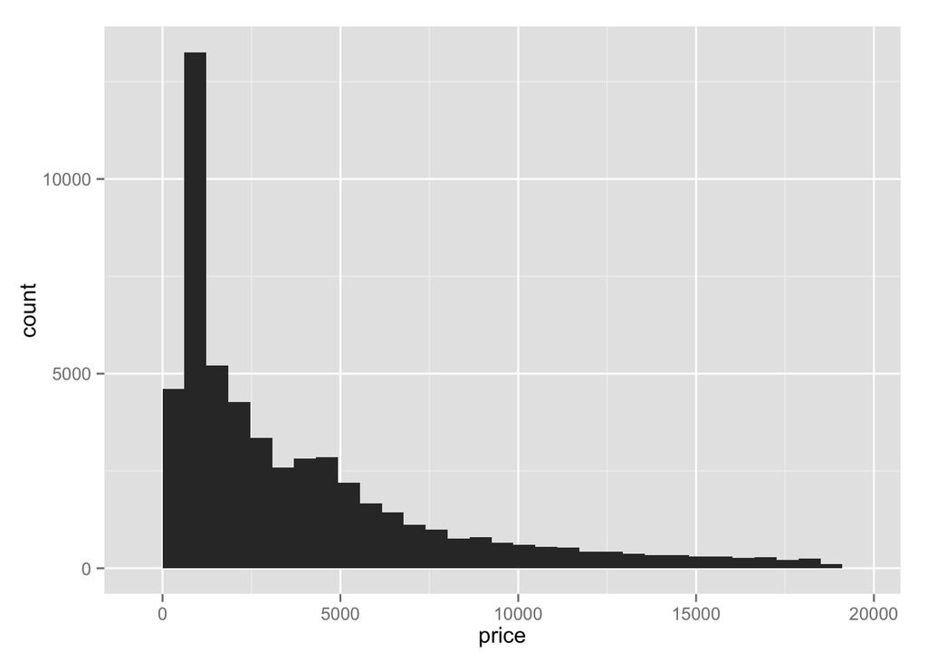

```r
ggplot(diamonds, aes(x = price)) +
         geom_histogram()
```

Set the bin width:

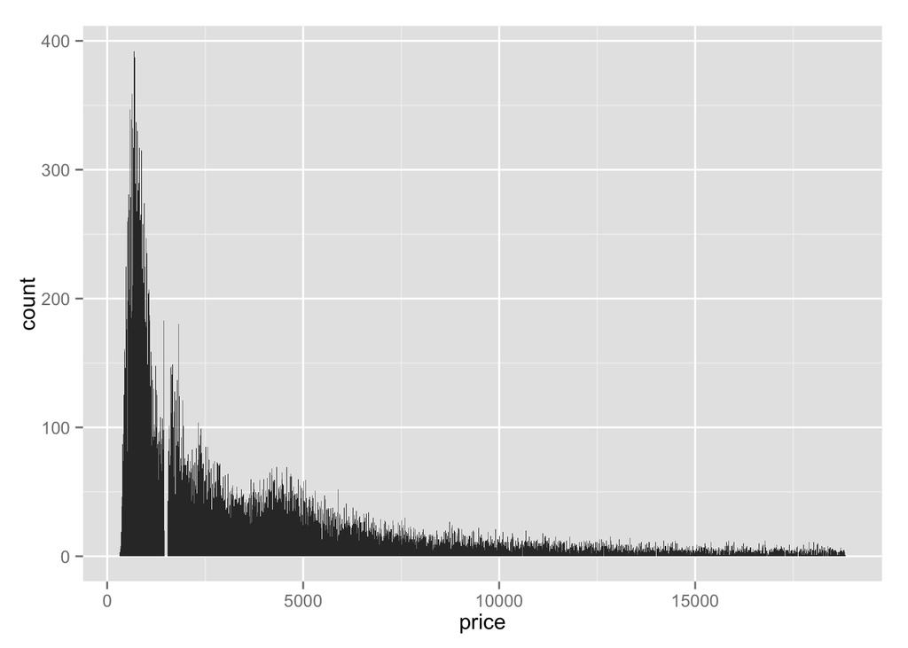

```r
ggplot(diamonds, aes(x = price)) +
         geom_histogram(binwidth = 10)
```

Use `geom_bar()` to create a bar chart

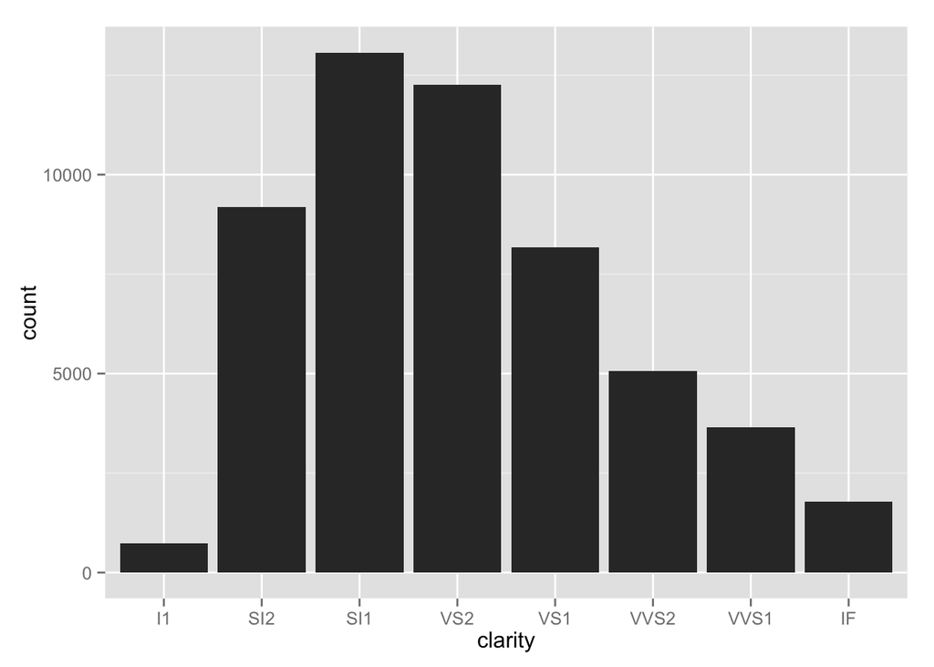

```r
ggplot(diamonds, aes(x = clarity)) +
  geom_bar()
```

.. or by group:

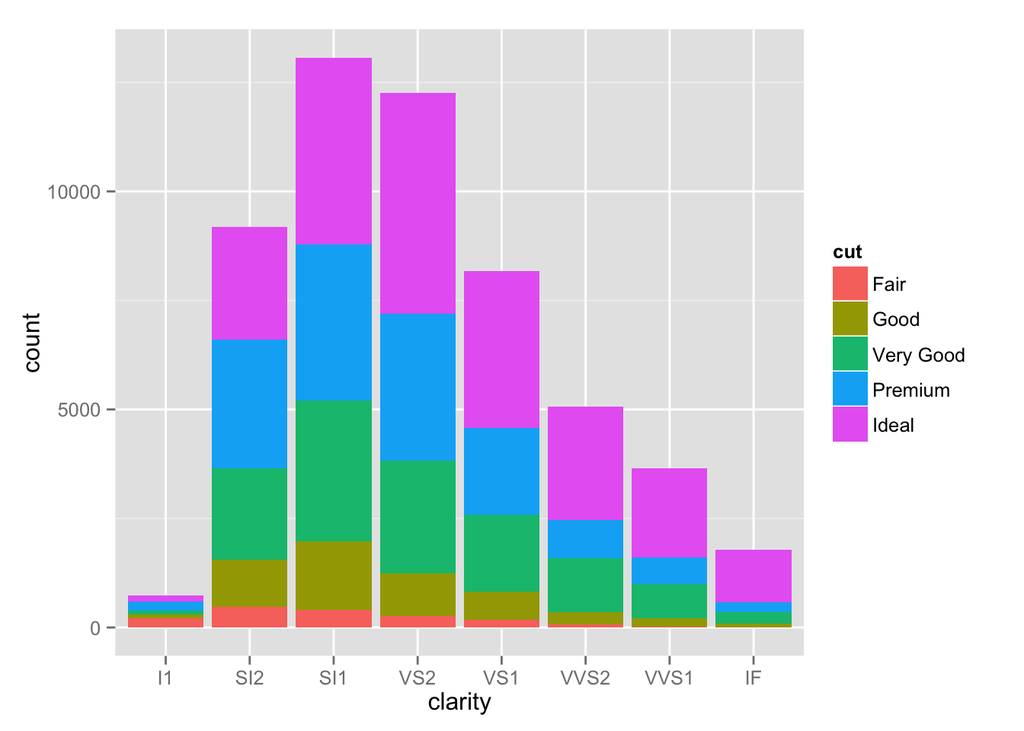

```r
ggplot(diamonds, aes(x = clarity)) +
  geom_histogram(aes(fill = cut))
```

Hide the legend:

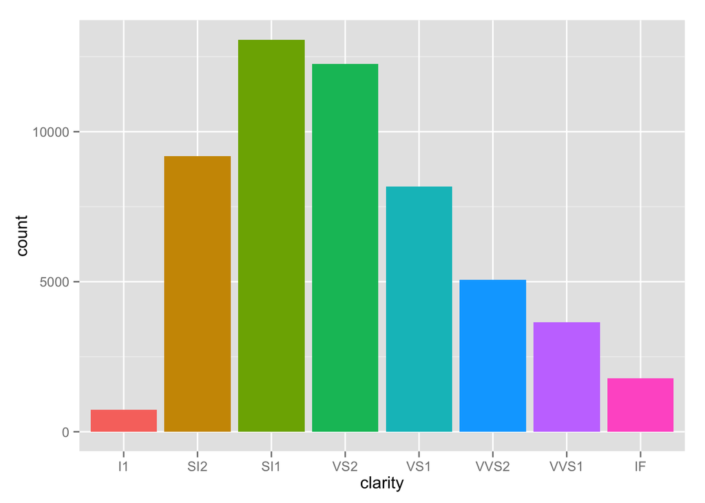

```r
ggplot(diamonds, aes(x = clarity)) +
  geom_histogram(aes(fill = clarity)) +
  theme(legend.position = "none")
```

Density

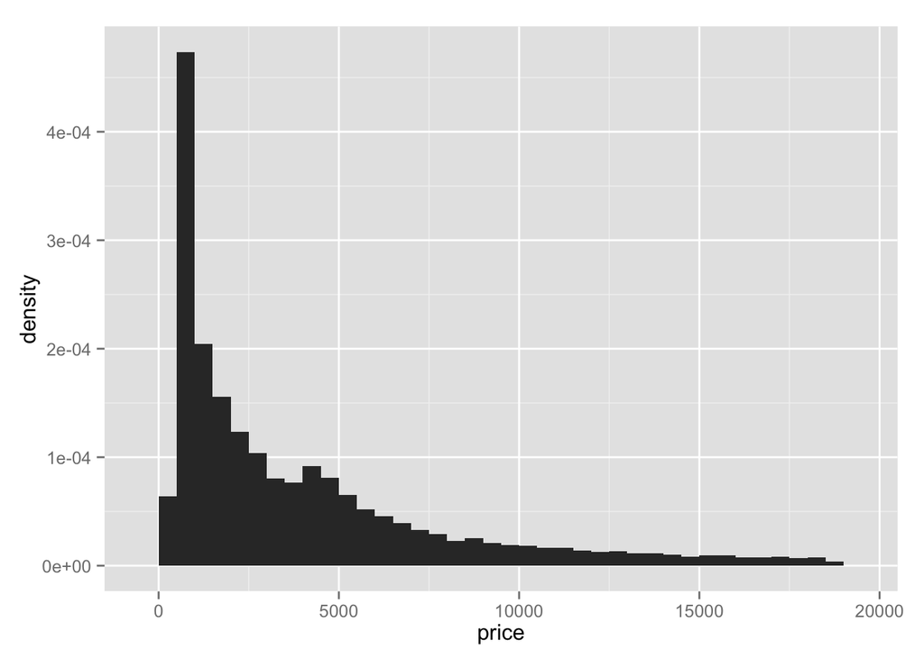

```r
ggplot(diamonds, aes(price)) +
  geom_histogram(aes(y = ..density..), binwidth = 500)
```

Density estimate:

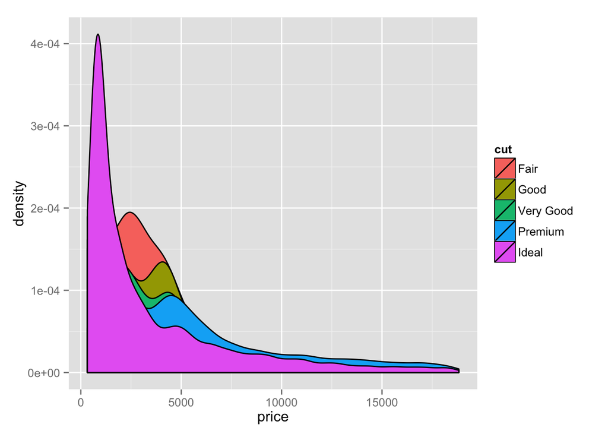

```r
ggplot(diamonds, aes(price)) +
  geom_density(aes(fill = cut))
```

Change the legend label:

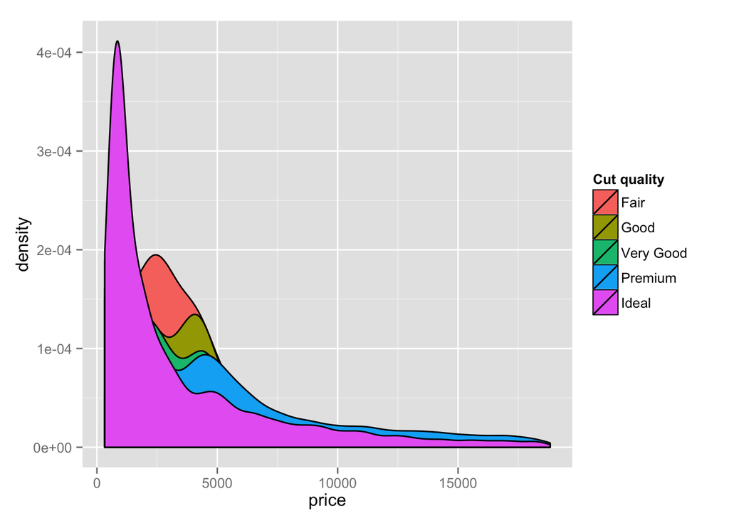

```r
ggplot(diamonds, aes(price)) +
  geom_density(aes(fill = cut)) +
  labs(fill = "Cut quality")
```

Change the theme:

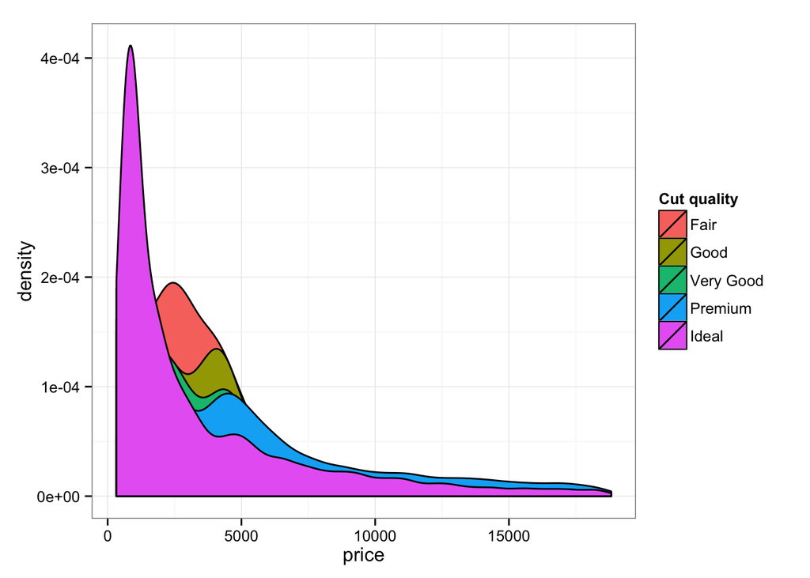

```r
ggplot(diamonds, aes(price)) +
  geom_density(aes(fill = cut)) +
  labs(fill = "Cut quality") +
  theme_bw()
```

## ggplot2 and ‘tidy’ data

Make sure you get data into a ‘tidy’ (long) form before using ggplot2. For example:

```r
library(dplyr)
library(tidyr)
library(readr)

unemployment <- read_csv("http://markwestcott34.github.io/economics/teaching/ss2015/R/datasets/uk_unemployment.csv")

head(unemployment)
```

```
## Source: local data frame [6 x 3]
##
##   Year Men Women
## 1 2000 5.9   4.9
## 2 2001 5.6   4.4
## 3 2002 5.8   4.5
## 4 2003 5.6   4.4
## 5 2004 5.1   4.3
## 6 2005 5.3   4.4
```

```r
unemployment_tidy <-
    gather(unemployment, key = Gender, value = "unemployment_rate", Men:Women)

head(unemployment_tidy %>% arrange(Year))
```

```
## Source: local data frame [6 x 3]
##
##   Year Gender unemployment_rate
## 1 2000    Men               5.9
## 2 2000  Women               4.9
## 3 2001    Men               5.6
## 4 2001  Women               4.4
## 5 2002    Men               5.8
## 6 2002  Women               4.5
```

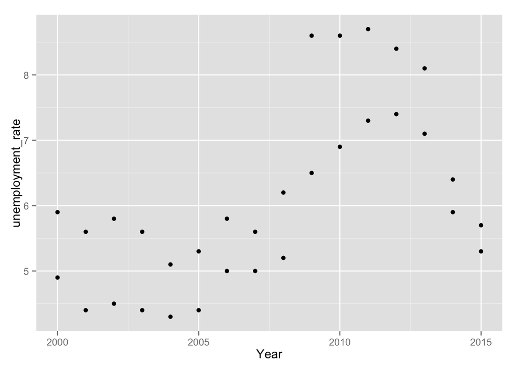

```r
ggplot(data = unemployment_tidy, aes(x = Year, y = unemployment_rate)) +
  geom_point()
```

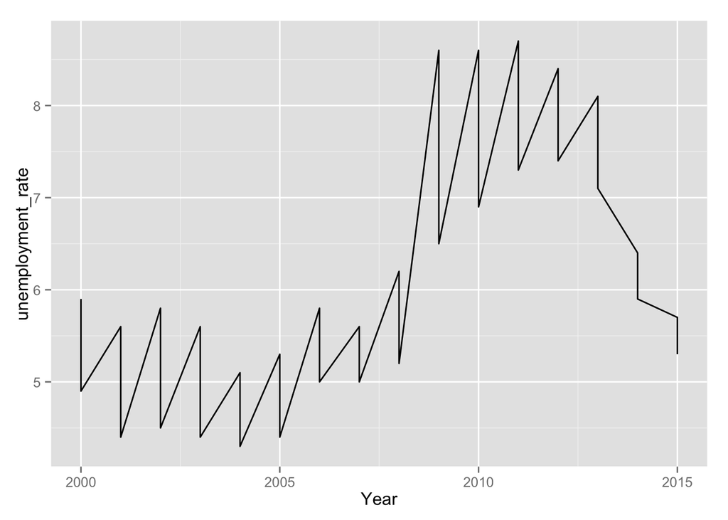

```r
ggplot(data = unemployment_tidy, aes(x = Year, y = unemployment_rate)) +
  geom_line()
```

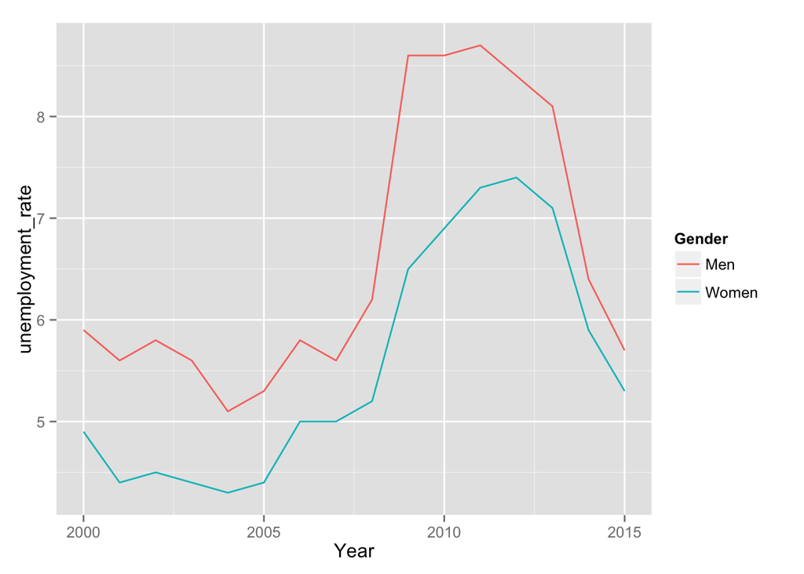

```r
ggplot(data = unemployment_tidy, aes(x = Year, y = unemployment_rate, color=Gender)) +
  geom_line()
```

## Scales

In order to control axis, size, colour, position, we use scales

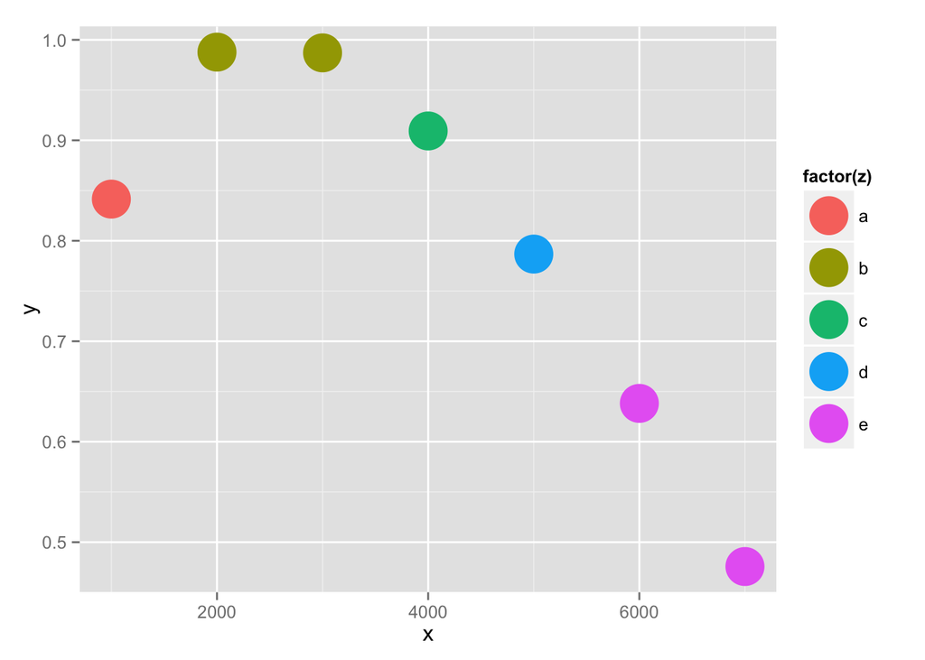

```r
df <- data.frame(x = (1:7) * 1000, y = sin(sqrt(1:7)), z = c("a","b","b","c","d","e","e"))
p <- ggplot(df, aes(x = x, y = y, colour = factor(z))) +
  geom_point(size = 10)

p
```

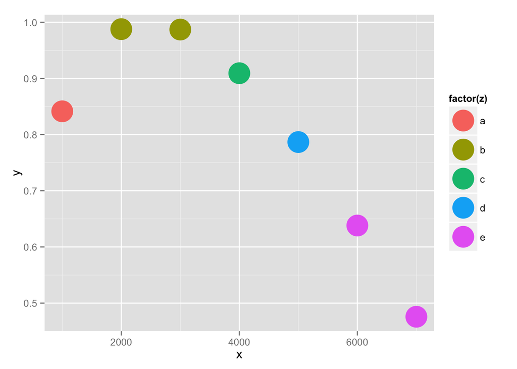

```r
  p + scale_x_continuous(breaks = c(2000, 4000,6000))
```

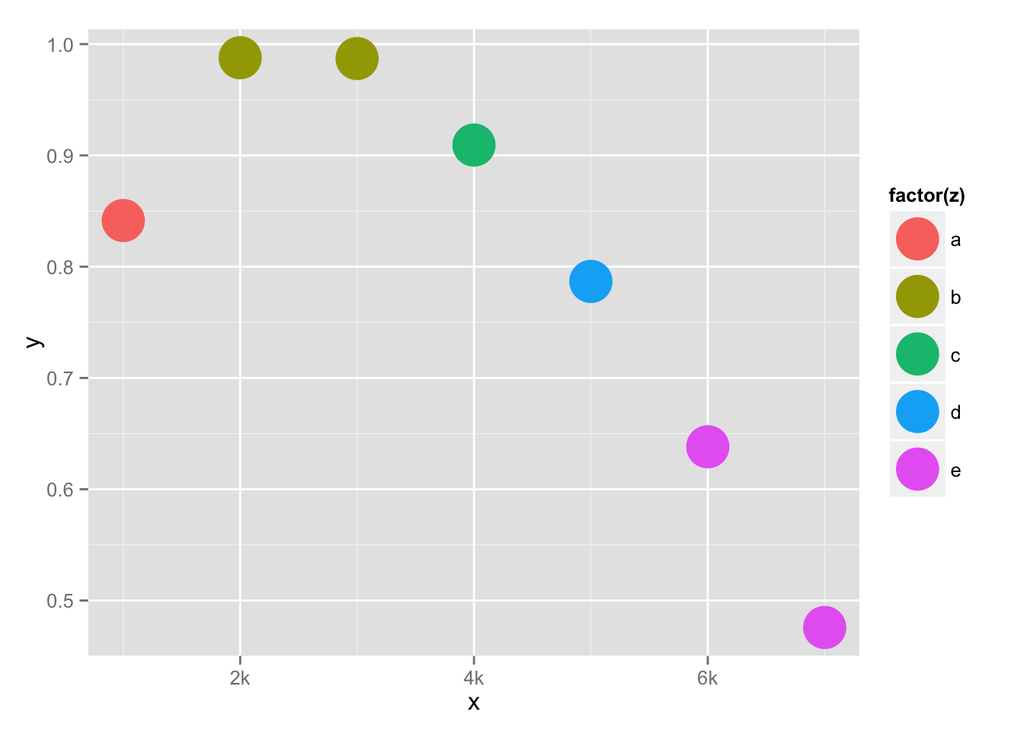

```r
  p + scale_x_continuous(breaks = c(2000, 4000,6000), labels = c("2k","4k","6k"))
```

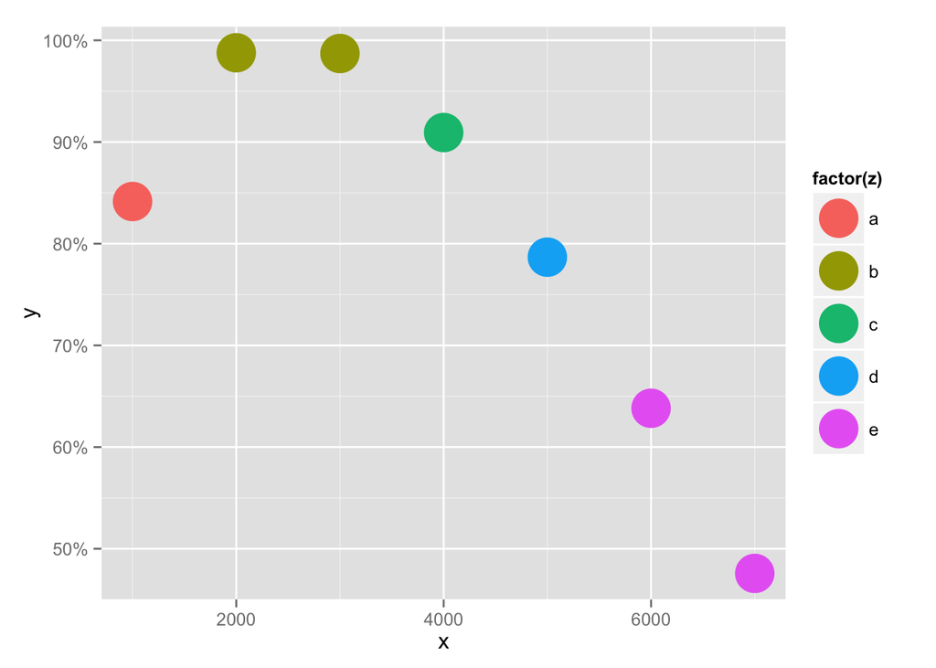

```r
  p + scale_x_continuous(breaks = c(2000, 4000,6000)) +
      scale_y_continuous(labels = scales::percent)
```

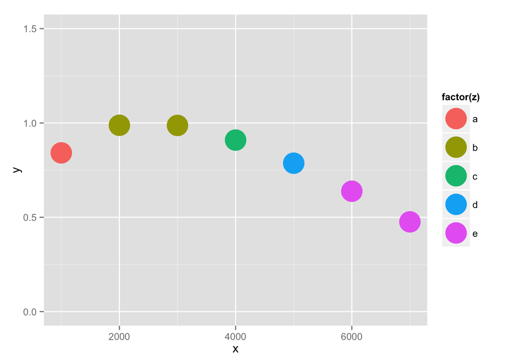

```r
  p + scale_y_continuous(limits = c(0,1.5))
```

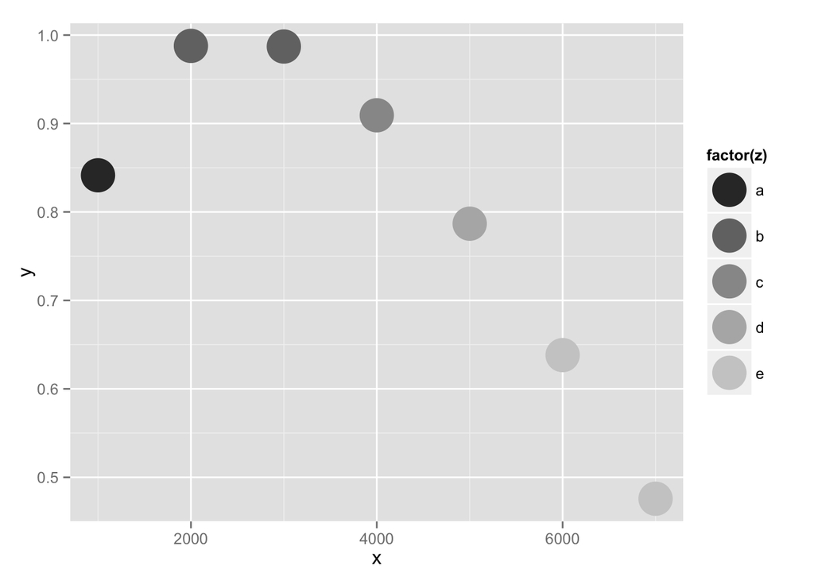

```r
  p + scale_colour_grey()
```

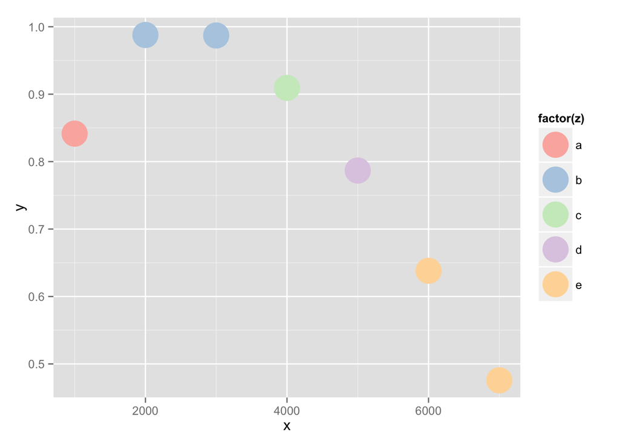

```r
  p + scale_colour_brewer(palette = "Pastel1") #See http://a2.typepad.com/6a0105360ba1c6970c01b7c7187af2970b-pi for available palettes
```

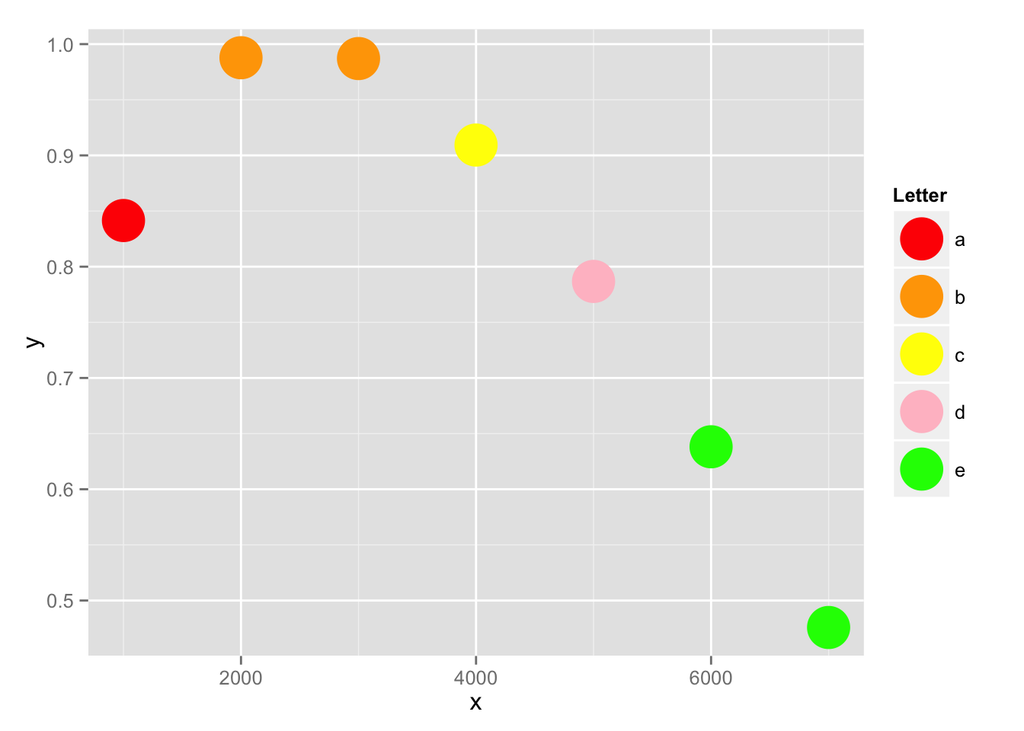

```r
  p + scale_color_manual("Letter", values = c("a" = "red", b = "orange", c = "yellow", d = "pink", e = "green"))
```

# Graph exercise

Try the following steps:

- Create a scatter plot
- Color points by region
- Add a quadratic smoothing line (hint: look at the ‘formula’ argument in the help for stat_smooth)
- Add labels (but only to some countries!)
- Set x and y axis titles

# Wrap up

We have hopefully covered everything you need to use R for your projects:

- basic operations
- vectors
- matrices
- lists
- *apply functions
- loading Stata/CSV data into R
- data frames (base R: creating, accessing, manipulating)
- regressions (OLS, probit, logit, robust SEs, bootstrapped SEs)
- dplyr for efficient data manipulation
- tidyr for reshaping and tidying data
- LaTeX/R integration
- graphs with ggplot2

# One last thing

I really hope you have enjoyed the course! Please fill out the feedback form at http://goo.gl/forms/TZE3OcJgyE so I can make improvements next time round.